# Reproducible_Research_Project_1

Benjamin Sila M

Tuesday, August 11, 2015

This is an R Markdown document.

## Introduction

It is now possible to collect a large amount of data about personal movement using activity monitoring devices such as a Fitbit, Nike Fuelband, or Jawbone Up. These type of devices are part of the “quantified self” movement – a group of enthusiasts who take measurements about themselves regularly to improve their health, to find patterns in their behavior, or because they are tech geeks. But these data remain under-utilized both because the raw data are hard to obtain and there is a lack of statistical methods and software for processing and interpreting the data.

This assignment makes use of data from a personal activity monitoring device. This device collects data at 5 minute intervals through out the day. The data consists of two months of data from an anonymous individual collected during the months of October and November, 2012 and include the number of steps taken in 5 minute intervals each day.

For more details on using R Markdown see http://rmarkdown.rstudio.com.

## Loading and preprocessing the data

1. Load the data (i.e. read.csv())

```r
activityData <- read.csv(unz("activity.zip", "activity.csv"), header=T, quote="\"", sep=",")
```

2. Process/transform the data (if necessary) into a format suitable for your analysis

```r
# Process/transform the data
activityData$date <- as.Date(activityData$date)
activityDataWithoutNAs <- activityData
activityDataWithoutNAs[is.na(activityDataWithoutNAs$steps), "steps"] <- 0
stepsPerDayWithoutNAs <- aggregate(steps ~ date, activityDataWithoutNAs, sum)
```

## What is mean total number of steps taken per day?

For this part of the assignment, you can ignore the missing values in the dataset.

1.Calculate the total number of steps taken per day.

```r
activityData$date <- as.Date(activityData$date)
activityData <- na.omit(activityData)
numberOfStepsTakenDaily <- rowsum(activityData$steps, format(activityData$date, '%Y-%m-%d'))
numberOfStepsTakenDaily <- data.frame(numberOfStepsTakenDaily)
names(numberOfStepsTakenDaily) <- ("steps")
```

2.If you do not understand the difference between a histogram and a barplot, research the difference between them. Make a histogram of the total number of steps taken each day.

[figure not shown]

```r
hist(stepsPerDayWithoutNAs$steps,
     main = "Histogram - Total Number of Steps Taken Daily (NA omitted)",
     xlab = "Steps",
     col = "purple",
     breaks = 8)
```

3. Calculate and report the mean and median total number of steps taken per day

```r
mean(stepsPerDayWithoutNAs$steps, na.rm = TRUE)
```

```
## [1] 9354.23
```

```r
median(stepsPerDayWithoutNAs$steps, na.rm = TRUE)
```

```
## [1] 10395
```

These formulas gives a mean and median of **9354.23** and **10395** respectively.

## What is the average daily activity pattern?

1. Make a time series plot (i.e. type = “l” ) of the 5-minute interval (x-axis) and the average number of steps taken, averaged across all days (y-axis)

```r
library(plyr)
avgNumberOfStepsInterval <- ddply(activityData, ~ interval, summarise, mean=mean(steps))
```

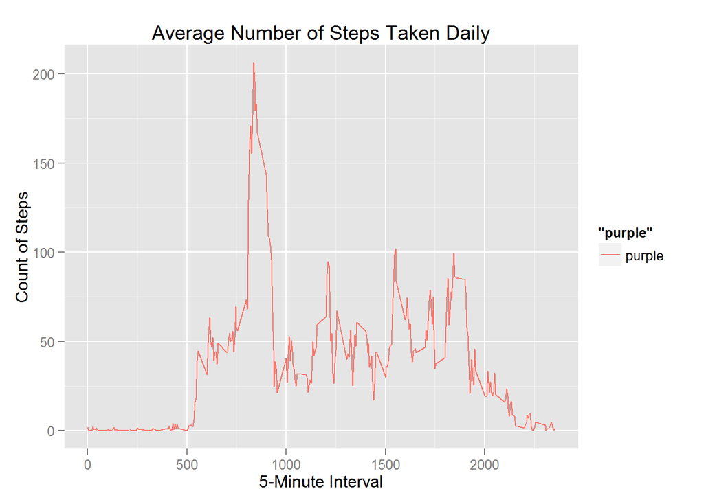

```r
library(ggplot2)
qplot(x=interval, y=mean, data = avgNumberOfStepsInterval,  geom = "line", xlab="5-Minute Interval", ylab="Count of Steps",
      main="Average Number of Steps Taken Daily", col = "purple")
```

2. Which 5-minute interval, on average across all the days in the dataset, contains the maximum number of steps?

```r
avgNumberOfStepsInterval[which.max(avgNumberOfStepsInterval$mean),]
```

```
##     interval     mean
## 104      835 206.1698
```

The 5-minute interval which contains the maximum number of steps is **835** across all days. The 5-minute interval mean is **206.1698**.

## Imputing missing values

Note that there are a number of days/intervals where there are missing values (coded as NA ). The presence of missing days may introduce bias into some calculations or summaries of the data.

1. Calculate and report the total number of missing values in the dataset (i.e. the total number of rows with NA s)

```r
incompleteData <- read.csv(unz("activity.zip", "activity.csv"), header=T, quote="\"", sep=",")
names(incompleteData) <- ("steps")
nrow(incompleteData[is.na(incompleteData$steps),])
```

```
## [1] 2304
```

The total number of rows with NAs is **2304**.

2.Devise a strategy for filling in all of the missing values in the dataset. The strategy does not need to be sophisticated. For example, you could use the mean/median for that day, or the mean for that 5-minute interval, etc.

```r
# load the data
activityData <- read.csv(unz("activity.zip", "activity.csv"), header=T, quote="\"", sep=",")
activityData$date <- as.Date(activityData$date)
activityDataWithoutNAs <- activityData
```

3.Create a new dataset that is equal to the original dataset but with the missing data filled in.

```r
activityDataWithoutNAs[is.na(activityDataWithoutNAs$steps), "steps"] <- 0
stepsPerDayWithoutNAs <- aggregate(steps ~ date, activityDataWithoutNAs, sum)
```

4.Make a histogram of the total number of steps taken each day

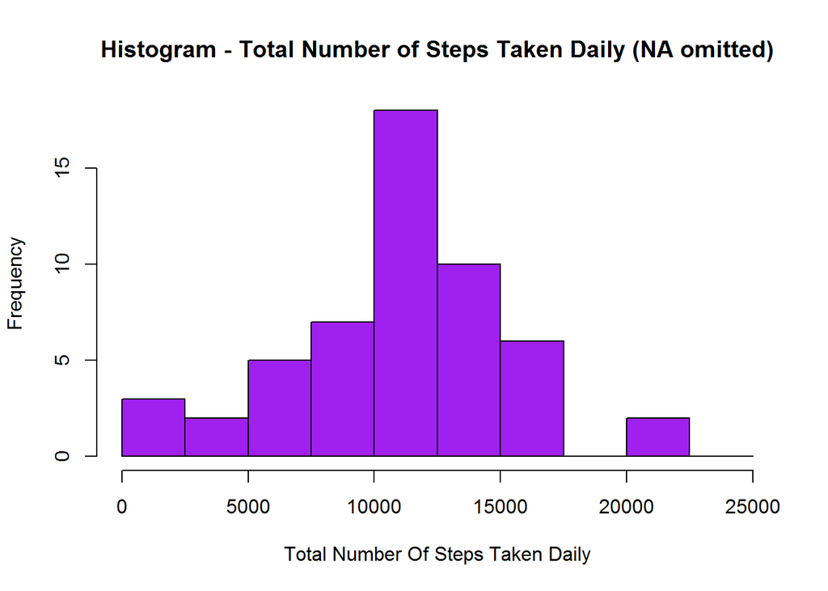

```r
# histogram of the total number of steps taken each day
hist(numberOfStepsTakenDaily$steps,
     main="Histogram - Total Number of Steps Taken Daily (NA omitted)",
     breaks=seq(from=0, to=25000, by=2500),
     xlab = "Total Number Of Steps Taken Daily",
     col = "purple")
```

And Calculate and report the mean and median total number of steps taken per day.

```r
mean(numberOfStepsTaken$steps)
```

[output not shown]

```r
median(numberOfStepsTaken$steps)
```

[output not shown]

## Are there differences in activity patterns between weekdays and weekends?

For this part the weekdays() function may be of some help here. Use the dataset with the filled-in missing values for this part.

1.Create a new factor variable in the dataset with two levels – “weekday” and “weekend” indicating whether a given date is a weekday or weekend day.

```r
weekdays <- c("Monday","Tuesday","Wednesday","Thursday","Friday")
activityData$dow = as.factor(ifelse(is.element(weekdays(as.Date(activityData$date)),weekdays), "Weekday", "Weekend"))
steps_by_interval_i <- aggregate(steps ~ interval + dow, activityData, mean)

# View the factor
head(steps_by_interval_i)
```

```
##   interval     dow     steps
## 1        0 Weekday 2.3333333
## 2        5 Weekday 0.4615385
## 3       10 Weekday 0.1794872
## 4       15 Weekday 0.2051282
## 5       20 Weekday 0.1025641
## 6       25 Weekday 1.5128205
```

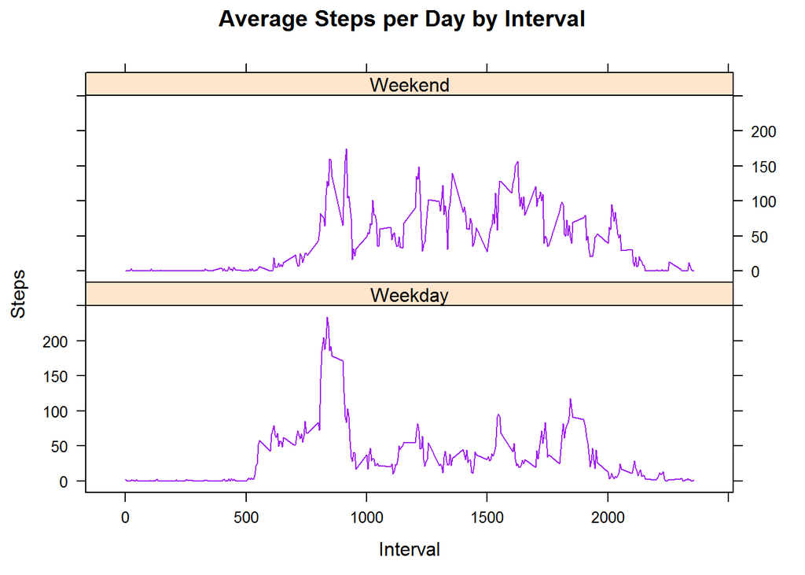

```r
# Load the lattice graphical library
library(lattice)

# Draw the Time Series Plot
xyplot(steps_by_interval_i$steps ~ steps_by_interval_i$interval|steps_by_interval_i$dow,
       main="Average Steps per Day by Interval",
       xlab="Interval",
       ylab="Steps",
       layout=c(1,2),
       type="l",
       col = "purple")
```